# HW3

Lance

2/2023

# Instructions

Before we get started, I wanted to let you know something about the data for this homework: it’s from the Transatlantic slave trade. This is a very sensitive subject, but I think it’s valuable for us to confront the vast extent of and role slavery played in the history of the U.S. and other parts of the world. Please take a moment to read [an introduction to this data here.](https://github.com/rfordatascience/tidytuesday/blob/master/data/2020/2020-06-16/readme.md) It does a good job of capturing my intent with this assignment.

However, my intent is irrelevant if you feel completing this assignment would be harmful to you. *If you are uncomfortable working with this data, please do not hesitate to reach out to me for a different dataset. You will not be judged or penalized in any way.*

This HW is worth 10 total points.

1. Make sure to load any packages you may need right at the start. Do *NOT* include the `learnr` package, ever, unless you are writing an interactive Tutorial (which you won’t do in this course) - this will cause problems.
2. Ensure that no chunks have the `include = FALSE` or `echo = FALSE` option, as I want to be able to see *all* your code and output.
3. Brief but descriptive headings and document organization (answers under headings, text near relevant code, brief explanatory text as necessary, etc.) (1 pt)

   Look to my HW1 and RMarkdown Organization examples for how to write good headings, organize your assignment, and how much narrative text (outside of code chunks) I want. But a good rule of thumb is: explain what YOU’RE doing, NOT what YOUR CODE is doing. I do NOT need to see a repeat, line-by-line narration of what your code does - you can use code comments for that. (In complex blocks you usually want at least a comment every few lines.) I DO want to see an overall summary of what you did in your analysis.
4. Figure out how to import the `slave_routes` data frame two ways:
   1. Using a single line of code in the linked introduction above to get the data directly from Github (0.3 pts),

      Comment out this code before you knit the assignment so it doesn’t run and try to pull the data every time you knit. Don’t delete it so I can still grade its correctness, but do comment it out once you successfully import the data this way for the first time and successfully export and re-import it locally in Q4ii.
   2. By saving the file to your local computer and importing it “manually” (as laid out in Tutorial 2.1). The easiest way to do this is probably to export the version you got from Github. *You must use working directory notation (i.e. a “./” rather than a full file path).* (0.7 pts)
5. Using a single continuous block of code with pipes (no intermediate stopping points) for each of the below sub-parts (3 blocks in total), give me output that shows:
   1. Which port received the largest total number of enslaved people (from ships with a known number of enslaved people), and what was that number? You may show more than one port, as long as the top port is visible. HINT: The top port should have received 683310 slaves. (2 pts)
   2. Which `ship_name` made the most journeys before the year 1800 (you may show more than one ship, as long as the top ship is visible), and during what years (prior to 1800) did it operate? Exclude the `NA` values of `ship_name` as part of your first `dplyr` verb.

      Note all the data you need to answer these questions should be visible in one piece of output. HINT: you may want the `min()` and `max()` functions. (2 pts)
   3. Which *two* `ship_name`s made the most journeys without a named captain, in any years? Exclude the `NA` values of `ship_name` as part of your first `dplyr` verb.

      HINT: you could either create a new variable that indicates whether the ship had a missing captain or not, or simply figure out a way to count only ship journeys with missing captains.

      You may show more than two ships, as long as the top two ships are visible. (2 pts)

   Provide about 1 sentence of narrative text that interprets the output and answers each question, i-iii.
6. Using *two* separate continuous blocks of code with pipes - one for any data manipulation, and then one for the visualization - produce a line graph of the number of total slaves that arrived in all ports by *decade* (again, only for ships with a known number of slaves; include all years in this analysis). Each decade must run from 0-9 (e.g. 1770-1779, not 1765-1774). Give the axes human-readable labels.

   HINT: You’ll have to create a new decade variable. If you need help, think back to how we extracted the hour and minute values from the military time in the `flights` data. You should *not* use `case_when()` to set a criterion for each individual decade; rather you should figure out a way to create this variable in 1-2 lines.

   Answer the following questions:
   1. In what decade did the Transatlantic slave trade peak?
   2. You can calculate this manually in a separate block, but in this decade approximately how many enslaved people were being transported across the Atlantic *per day*? (3 pts)

**To submit this assignment:**

Ideally, knit straight to PDF by changing `html_document` to `pdf_document` in line 5 above. Otherwise:

1. Knit to HTML. An HTML document should open automatically in another RStudio window.
2. Click “Open in Browser” in that HTML document. It should open as a webpage in your default browser (e.g. Chrome).
3. Click Ctrl+P/Command+P, but instead of printing a hard copy on your printer click “Save as PDF.”
4. Save and upload that document to Canvas.

A note on PDF formatting: you may notice that long lines of code “fly off the side of the page” when you knit to PDF. To fix this:

*If you’re on a Windows machine*:

- Install the `formatR` package
- Change your `opts_chunk$set` code line to the following: `knitr::opts_chunk$set(echo = TRUE, tidy.opts=list(width.cutoff=80), tidy=TRUE)`

That should force your code to always wrap rather than fly off the edge of the page of a PDF. Note this does not fix issues of, say, plot titles that are too long getting cut off. But it should fix all the errors with your code not wrapping. Happy PDFing!

*If you’re on a Mac*: I don’t have an easy solution for you. Try and keep your lines of code under about 80 characters. Feel free to use more vertical lines of code to accomplish this. But don’t waste large amounts of time formatting. I’ll ask you for clarification if something critical is missing.

——BEGIN ANSWER BELOW——–

Before we begin our analysis, we will first load the necessary packages.

```r
pacman::p_load(tidyverse)

# 1 liner
#slave_routes <- readr::read_csv('https://raw.githubusercontent.com/rfordatascience/tidytuesday/master/data/2020/2020-06-16/slave_routes.csv')
```

```r
#write_csv(slave_routes, "./slave_routes.csv")
slave_routes = read_csv("./slave_routes.csv")
# Check that it is working
knitr::kable(head(slave_routes, n=5))
```

| voyage_id | ship_name | port_origin | place_of_purchase | port_arrival | year_arrival | n_slaves_arrived | captains_name |
| --- | --- | --- | --- | --- | --- | --- | --- |
| 81711 | Hannah | Liverpool | Calabar | St. Vincent, port unspecified | 1787 | 390 | Smith, Bryan |
| 81712 | Hannah | Liverpool | New Calabar | Grenada, port unspecified | 1789 | 351 | Wilson, Charles |
| 81713 | Hannah | Liverpool | Bight of Biafra and Gulf of Guinea Islands, port unspecified | Kingston | 1789 | 303 | Wilson, Charles |
| 81714 | Hannah | Liverpool | Bonny | St. Vincent, port unspecified | 1791 | 316 | Young, William |
| 81715 | Hannah | Liverpool | Congo River | Grenada, port unspecified | 1792 | 331 | Young, William |

We are getting an output, and I can see in my local file explorer that I have the new file `slave_routes.csv`. We are now ready to begin.

# Analyzing `slave_routes` with data transformations

### Port receiving the largest total number of enslaved people

```r
slave_routes %>%
  select(port_arrival, n_slaves_arrived) %>%
  group_by(port_arrival) %>%
  summarize(n_ships_port = n(),
            n_slaves_port = sum(n_slaves_arrived, na.rm=TRUE)
            ) %>%
  arrange(desc(n_slaves_port)) %>%
  head(n=5) %>%
  knitr::kable()
```

| port_arrival | n_ships_port | n_slaves_port |
| --- | --- | --- |
| Rio de Janeiro | 2887 | 683310 |
| Bahia, port unspecified | 4223 | 549810 |
| Kingston | 1622 | 439916 |
| Barbados, port unspecified | 2038 | 275703 |
| Cap Francais | 1127 | 272983 |

We see that Rio de Janeiro had the most slaves at 683310, followed by Bahia at 549810 and Kingston at 439916.

### Ship with the most journeys made before the year 1800

We want to find the details of the ship that made the most number of trips before the year 1800. We will first remove all the nameless ships and the records from 1800 and onwards using `filter()`. We will then group by `ship_name` and use the `min()` and `max()` functions to find the earliest and latest recorded trips of each eligible ship, then sort the entire thing in descending order with a combination of `arrange()` and `desc()`.

```r
slave_routes %>%
  filter(!is.na(ship_name) & year_arrival < 1800) %>%
  select(ship_name, year_arrival) %>%
  group_by(ship_name) %>%
  summarize(n_trips = n(),
            first_trip = min(year_arrival),
            last_trip = max(year_arrival)) %>%
  arrange(desc(n_trips)) %>%
  head(n=5) %>%
  knitr::kable()
```

| ship_name | n_trips | first_trip | last_trip |
| --- | --- | --- | --- |
| Mary | 211 | 1645 | 1799 |
| Nancy | 183 | 1711 | 1799 |
| NS do Rosario S Antônio e Almas | 182 | 1698 | 1797 |
| NS da Conceição S Antônio e Almas | 175 | 1687 | 1796 |
| Africa | 138 | 1668 | 1799 |

We see that the *Mary* has made 211 trips before the year 1800, and has been in operation from at least 1645 to 1799.

### Ships with the most journeys without recorded captains

We want to find the 2 ships that made the most trips without a named captain in any years. We will first exclude ships without a name, as well as trips with captain names using `filter()`. We then group by `ship_name` and create an intermediate variable `n_trips`, which we use to count the number of trips each ship has made without a captain. We then use `arrange()` and `desc()` to sort the dataframe.

```r
slave_routes %>%
  filter(!is.na(ship_name) & is.na(captains_name)) %>%
  group_by(ship_name) %>%
  summarize(n_trips = n()) %>%
  arrange(desc(n_trips)) %>%
  head(n=5) %>%
  knitr::kable()
```

| ship_name | n_trips |
| --- | --- |
| Esperança | 18 |
| NS do Rosario S Antônio e Almas | 18 |
| NS da Conceição S Antônio e Almas | 15 |
| NS da Conceição | 13 |
| Carolina | 12 |

We can see that the *Esperança* and the *NS do Rosario S Antônio e Almas* both made 18 trips without a named captain.

## Number of Total Slaves that arrived in all ports by decade

We will count the number of slaves transported every decade by summing the known slave arrivals in that decade. We will perform integer division `%/%` to find the decade of the trip, then group all trips with known slave arrivals by decade. We then sort it by descending order with `arrange()` and `desc()` for easier viewing.

```r
slave_decades <- slave_routes %>%
  filter(!is.na(n_slaves_arrived)) %>%
  select(year_arrival, n_slaves_arrived) %>%
  mutate(decade = 10 * (year_arrival %/% 10)) %>%
  group_by(decade) %>%
  summarize(n_slaves_decade = sum(n_slaves_arrived)) %>%
  arrange(desc(n_slaves_decade))

knitr::kable(head(slave_decades, n=10))
```

| decade | n_slaves_decade |
| --- | --- |
| 1790 | 510082 |
| 1820 | 452344 |
| 1800 | 441944 |
| 1780 | 419573 |
| 1760 | 378691 |
| 1810 | 374430 |
| 1770 | 320324 |
| 1840 | 304277 |
| 1830 | 261760 |
| 1750 | 255050 |

To plot this data, we will use a ggplot `geom_line()` line plot. We change the number of breaks and minor breaks for easier viewing, and change the labels for human readability. The y-axis is left in exponential form for less clutter.

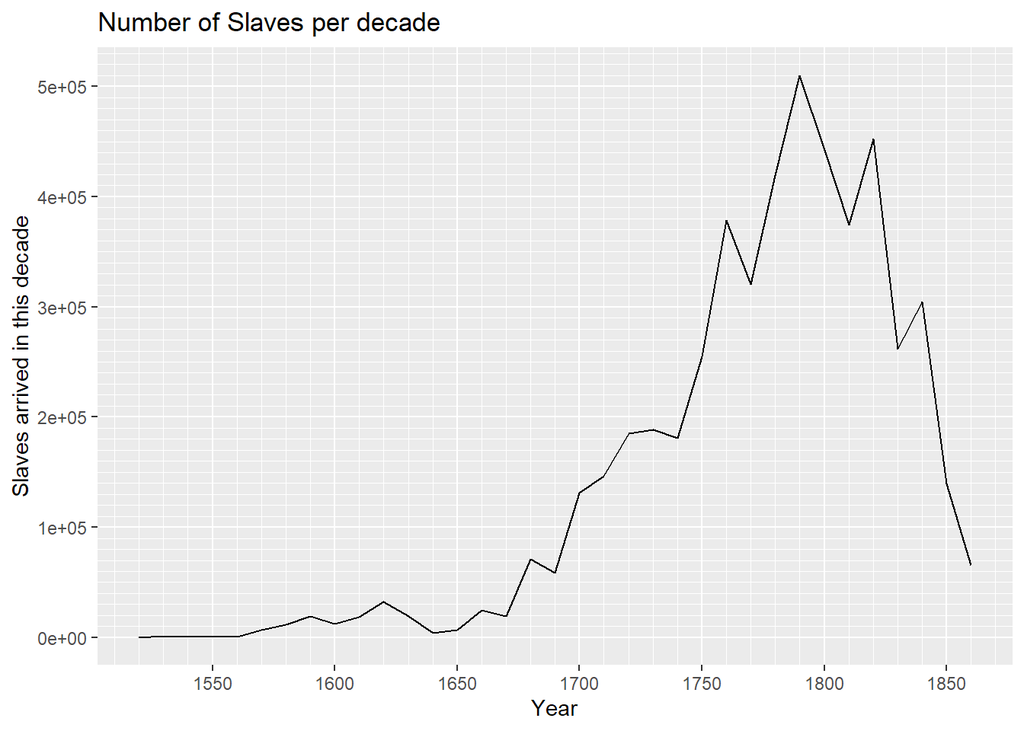

```r
ggplot(slave_decades) +
  geom_line(aes(x=decade, y=n_slaves_decade)) +
  scale_x_continuous(n.breaks=10,
                     minor_breaks = seq(1500,1900,10)) +
  labs(title = "Number of Slaves per decade") +
  scale_y_continuous(minor_breaks = seq(0,550000,10000)) +
  xlab("Year") +
  ylab("Slaves arrived in this decade")
```

```r
# I wasn't sure how (or why) to utilize pipes for ggplot since everything is a noun and we wouldn't need pipes.
```

The slave trade (from what we can see in this dataset) peaked in the decade of 1790-1799, as indicated by the highest peak at that time. To find how many slaves were being transported per day during that decade:

```r
slave_count <- slave_decades[1,2]

print(slave_count/(365.25*10))
```

```
##   n_slaves_decade
## 1        139.6528
```